167341 — Zorzi Luca

# **Analisi sui dati del gioco televisivo "Affari Tuoi"**

10/07/2024 — Università degli Studi di Udine

## **Il gioco in breve**

- Ogni pacco contiene dei soldi, i premi nei pacchi aperti vengono persi
- Il "Dottore" conosce il contenuto dei pacchi
- Il "Dottore" può proporre un'offerta monetaria

[figure not shown]

## **Cosa vorrei scoprire?**

1. Ci sono pacchi più fortunati di altri?
2. È possibile prevedere le offerte del dottore?
3. È possibile scoprire in anticipo il premio del concorrente?
4. Pacco vs Offerta: con cosa conviene vincere?

### **Raccolta dati**

- **Periodo**: dal 12/02/2024 al 20/05/2024
- **Strumenti**: Software con GUI creato da me

### **Dataset**

**Dati raccolti:**

- Azioni di gioco e relativi stati
- Contenuto pacchi
- Vincita e tipo vincita

**Dati derivati:**

- Premi rimasti in gioco dopo ogni azione
- Media premi rimasti dopo ogni azione
- Premio in mano al concorrente

**Dati mancanti ma interessanti:**

- Budget Rai per il programma
- Prezzo giornaliero per le inserzioni
- Numero di inserzioni per puntata

[figure not shown]

## **1) Ci sono pacchi più fortunati di altri?**

Metriche per l'analisi:

- **Somma cumulativa** dei premi per ogni pacco
- Distrubuzione dei premi per ogni pacco

### **1) Ci sono pacchi più fortunati di altri?**

#### **Somma cumulativa dei premi nel tempo**

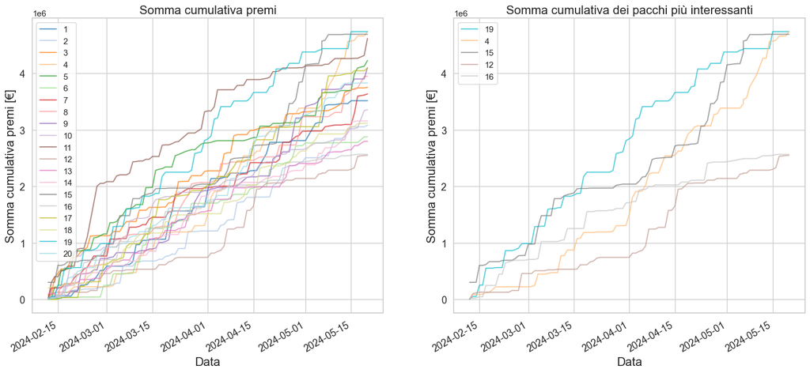

### **1) Ci sono pacchi più fortunati di altri?**

#### **Distribuzione dei premi nei pacchi**

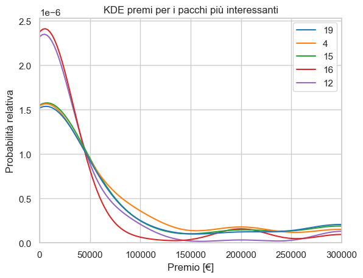

### **1) Ci sono pacchi più fortunati di altri?**

#### **Distribuzione dei premi nei pacchi**

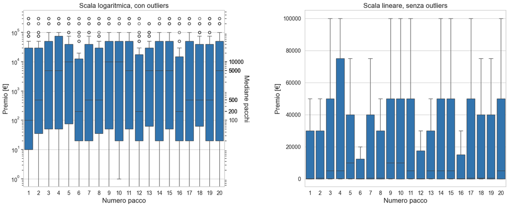

## **2) È possibile prevedere le offerte del dottore?**

Come arrivare al risultato:

- Correlazione tra **media dei premi in gioco** e **valore delle offerte**
- Previsione delle offerte del dottore tramite un modello di regressione lineare

### **2) È possibile prevedere le offerte del dottore?**

#### **Coefficienti di correlazione**

Correlazione tra **media dei premi in gioco** e **valore delle offerte** secondo i coefficienti di **Pearson**, **Spearman** e **Kendall**:

- **Pearson**:

  0.8907 p=3.55e-132
- **Spearman**:

  0.8746 p=1.57e-121
- **Kendall**:

  0.7145 p=4.71e-94

Correlazione positiva con bassa probabilità che sia dovuta al caso.

### **2) È possibile prevedere le offerte del dottore?**

#### **Retta di regressione**

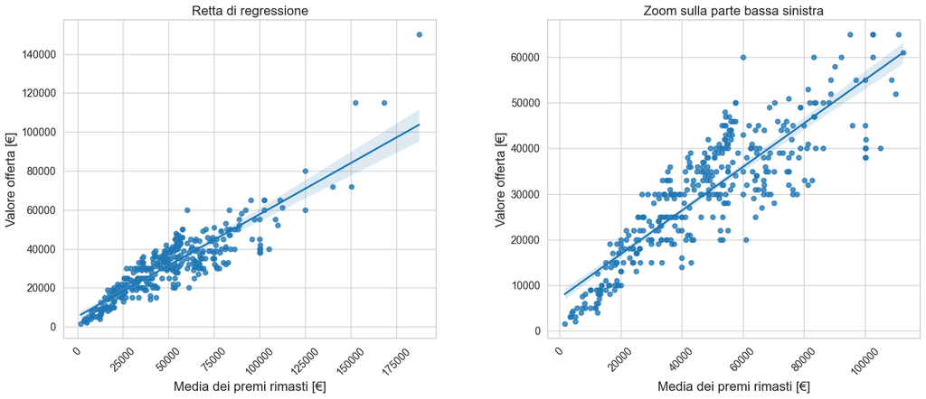

### **2) È possibile prevedere le offerte del dottore?**

#### **Modello di regressione lineare**

Principali metriche per la valutazione di un modello di **regressione lineare**:

- **R<sup>2</sup>**:

  0.726
- **Mean Absolute Error (MAE)**:

  5933.6[€]
- **Root Mean Squared Error (RMSE)**:

  7618.8[€]

## **3) È possibile scoprire in anticipo il premio del concorrente?**

Come arrivare al risultato:

- Utilizzo dei risultati precedentemente visti
- Si prova ad aggiungere il premio in mano al concorrente come variabile dipendente, ponendo offerta e media dei premi come variabili indipendenti
- Valutazione della correlazione e allenamento di un modello di regressione lineare

### **3) È possibile scoprire in anticipo il premio del concorrente?**

#### **Correlazione tra offerte, media premi rimasti e premio concorrente**

|  |  | Premio concorrente |
| --- | --- | --- |
| Pearson | Valore offerta | 0.3495 |
|  | Media premi in gioco | 0.3068 |
| Spearman | Valore offerta | 0.1909 |
|  | Media premi in gioco | 0.1155 |
| Kendall | Valore offerta | 0.1349 |
|  | Media premi in gioco | 0.0850 |

### **3) È possibile scoprire in anticipo il premio del concorrente?**

#### **Modello di regressione lineare**

Principali metriche per la valutazione di un modello di **regressione lineare**:

- **R<sup>2</sup>**:

  -0.011
- **Mean Absolute Error (MAE)**:

  64008.1[€]
- **Root Mean Squared Error (RMSE)**:

  90903.6[€]

### **4) Pacco vs Offerta: con cosa conviene vincere?**

#### **Analisi distribuzione delle vincite**

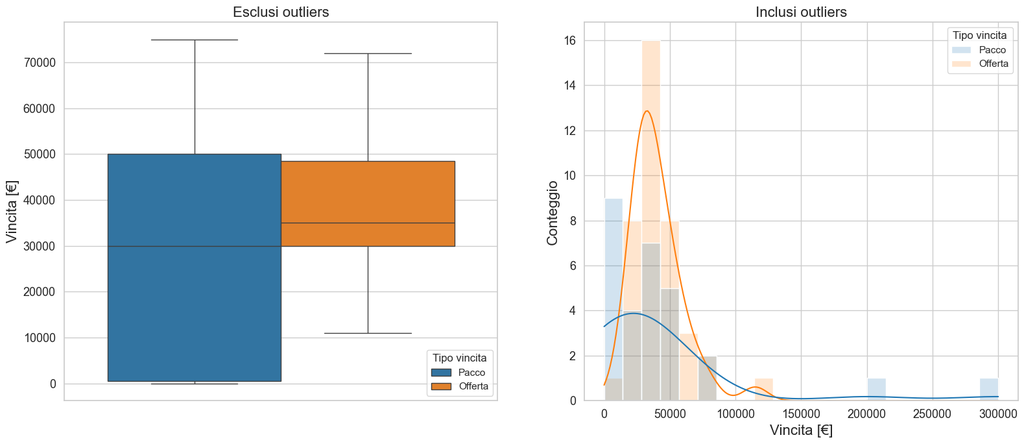

### **Conclusioni**

#### **Cosa abbiamo scoperto dalle analisi?**

Ci sono pacchi più fortunati di altri?

- A breve termine sembrerebbe di sì.

È possibile prevedere le offerte del dottore?

- Sì, con sufficiente accuratezza.

È possibile scoprire in anticipo il premio del concorrente?

- Non con i metodi utilizzati.

Pacco vs Offerta: con cosa conviene vincere?

- L'offerta è meno proficua ma più sicura.